# Balance energetico

Marc

2025-05-26

```r
library(readr)

# Cargar archivos
bal <- read_csv("balance_todas_comunidades.csv", show_col_types = FALSE)
gen <- read_csv("generacion_todas_comunidades.csv", show_col_types = FALSE)
```

```r
library(dplyr)
# Ver estructura general
glimpse(bal)
```

```
## Rows: 5,592
## Columns: 4
## $ variable  <chr> "Hidráulica", "Hidráulica", "Hidráulica", "Hidráulica", "Hid…
## $ comunidad <chr> "andalucia", "andalucia", "andalucia", "andalucia", "andaluc…
## $ fecha     <date> 2023-01-01, 2023-02-01, 2023-03-01, 2023-04-01, 2023-05-01,…
## $ valor     <dbl> 18407.598, 10515.175, 14122.596, 24457.044, 18438.120, 20903…
```

```r
# Ver nombres únicos de variables energéticas
unique(bal$variable)
```

```
##  [1] "Hidráulica"              "Eólica"
##  [3] "Solar fotovoltaica"      "Solar térmica"
##  [5] "Otras renovables"        "Generación renovable"
##  [7] "Ciclo combinado"         "Carbón"
##  [9] "Cogeneración"            "Residuos no renovables"
## [11] "Generación no renovable" "Turbinación bombeo"
## [13] "Consumo bombeo"          "Saldo almacenamiento"
## [15] "Saldo de intercambios"   "Demanda en b.c."
## [17] "Residuos renovables"     "Nuclear"
## [19] "Entrega batería"         "Carga batería"
## [21] "Fuel + Gas"              "Motores diésel"
## [23] "Turbina de gas"          "Hidroeólica"
```

```r
# Ver nombres únicos de comunidades
unique(bal$comunidad)
```

```
##  [1] "andalucia"           "aragon"              "asturias"
##  [4] "cantabria"           "castillalamancha"    "castillayleon"
##  [7] "cataluna"            "comunidadValenciana" "extremadura"
## [10] "galicia"             "islasbaleares"       "islascanarias"
## [13] "larioja"             "madrid"              "murcia"
## [16] "navarra"             "paisvasco"
```

```r
# Revisar si hay valores NA y en qué proporción
summary(bal)
```

```
##    variable          comunidad             fecha                valor
##  Length:5592        Length:5592        Min.   :2023-01-01   Min.   :-3106158
##  Class :character   Class :character   1st Qu.:2023-06-23   1st Qu.:    4112
##  Mode  :character   Mode  :character   Median :2023-12-16   Median :   47876
##                                        Mean   :2023-12-16   Mean   :  269503
##                                        3rd Qu.:2024-06-08   3rd Qu.:  310699
##                                        Max.   :2024-12-01   Max.   : 4187142
##                                                             NA's   :125
```

```r
# Contar valores faltantes por variable energética
bal %>%
  group_by(variable) %>%
  summarise(n_total = n(), n_NA = sum(is.na(valor)), porc_NA = mean(is.na(valor))*100) %>%
  arrange(desc(porc_NA))
```

```
## # A tibble: 24 × 4
##    variable               n_total  n_NA porc_NA
##    <chr>                    <int> <int>   <dbl>
##  1 Fuel + Gas                  24    19  79.2
##  2 Carbón                      96    45  46.9
##  3 Entrega batería             72    19  26.4
##  4 Carga batería               72    15  20.8
##  5 Saldo almacenamiento       288    11   3.82
##  6 Eólica                     384    13   3.39
##  7 Residuos no renovables     240     2   0.833
##  8 Ciclo combinado            312     1   0.321
##  9 Cogeneración               384     0   0
## 10 Consumo bombeo             240     0   0
## # ℹ 14 more rows
```

```r
library(dplyr)

# Ver estructura general
glimpse(gen)
```

```
## Rows: 3,480
## Columns: 4
## $ variable  <chr> "Hidráulica", "Carbón", "Ciclo combinado", "Eólica", "Solar …
## $ comunidad <chr> "Andalucia", "Andalucia", "Andalucia", "Andalucia", "Andaluc…
## $ valor     <dbl> 18407.598, 42254.524, 435705.037, 552635.226, 429269.280, 60…
## $ fecha     <date> 2023-01-01, 2023-01-01, 2023-01-01, 2023-01-01, 2023-01-01,…
```

```r
# Ver nombres únicos de variables energéticas
unique(gen$variable)
```

```
##  [1] "Hidráulica"             "Carbón"                 "Ciclo combinado"
##  [4] "Eólica"                 "Solar fotovoltaica"     "Solar térmica"
##  [7] "Otras renovables"       "Cogeneración"           "Residuos no renovables"
## [10] "Generación total"       "Residuos renovables"    "Nuclear"
## [13] "Fuel + Gas"             "Motores diésel"         "Turbina de gas"
## [16] "Turbina de vapor"       "Hidroeólica"
```

```r
# Ver nombres únicos de comunidades
unique(gen$comunidad)
```

```
##  [1] "Andalucia"           "Aragon"              "Asturias"
##  [4] "Cantabria"           "Castillalamancha"    "Castillayleon"
##  [7] "Cataluna"            "Comunidadvalenciana" "Extremadura"
## [10] "Galicia"             "Islas Baleares"      "Islas Canarias"
## [13] "Larioja"             "Madrid"              "Murcia"
## [16] "Navarra"             "Pais Vasco"
```

```r
# Revisar si hay valores NA y en qué proporción
summary(bal)
```

```
##    variable          comunidad             fecha                valor
##  Length:5592        Length:5592        Min.   :2023-01-01   Min.   :-3106158
##  Class :character   Class :character   1st Qu.:2023-06-23   1st Qu.:    4112
##  Mode  :character   Mode  :character   Median :2023-12-16   Median :   47876
##                                        Mean   :2023-12-16   Mean   :  269503
##                                        3rd Qu.:2024-06-08   3rd Qu.:  310699
##                                        Max.   :2024-12-01   Max.   : 4187142
##                                                             NA's   :125
```

```r
# Contar valores faltantes por variable energética
bal %>%
  group_by(variable) %>%
  summarise(n_total = n(), n_NA = sum(is.na(valor)), porc_NA = mean(is.na(valor))*100) %>%
  arrange(desc(porc_NA))
```

```
## # A tibble: 24 × 4
##    variable               n_total  n_NA porc_NA
##    <chr>                    <int> <int>   <dbl>
##  1 Fuel + Gas                  24    19  79.2
##  2 Carbón                      96    45  46.9
##  3 Entrega batería             72    19  26.4
##  4 Carga batería               72    15  20.8
##  5 Saldo almacenamiento       288    11   3.82
##  6 Eólica                     384    13   3.39
##  7 Residuos no renovables     240     2   0.833
##  8 Ciclo combinado            312     1   0.321
##  9 Cogeneración               384     0   0
## 10 Consumo bombeo             240     0   0
## # ℹ 14 more rows
```

Estudio indice de autosuficiencia

```r
library(stringr)

gen_filtrado <- gen %>%
  group_by(comunidad, fecha) %>%
  summarise(generacion = sum(valor, na.rm = TRUE), .groups = "drop")


# Normaliza generación
gen_filtrado <- gen %>%
  group_by(comunidad, fecha) %>%
  summarise(generacion = sum(valor, na.rm = TRUE), .groups = "drop") %>%
  mutate(
    comunidad = str_replace_all(tolower(comunidad), "[[:space:]]", ""),
    fecha = as.Date(fecha)  # fuerza tipo Date
  )

# Normaliza balance
bal_filtrado <- bal %>%
  filter(variable == "Demanda en b.c.") %>%
  mutate(
    comunidad = str_replace_all(tolower(comunidad), "[[:space:]]", ""),
    fecha = as.Date(fecha)  # fuerza tipo Date
  ) %>%
  select(comunidad, fecha, demanda = valor)


df_final <- left_join(gen_filtrado, bal_filtrado, by = c("comunidad", "fecha")) %>%
  mutate(indice_autosuficiencia = generacion / demanda)
```

```r
df_final %>%
  filter(!is.na(indice_autosuficiencia), is.finite(indice_autosuficiencia)) %>%
  group_by(comunidad) %>%
  summarise(media_autosuficiencia = mean(indice_autosuficiencia)) %>%
  arrange(desc(media_autosuficiencia))
```

```
## # A tibble: 16 × 2
##    comunidad           media_autosuficiencia
##    <chr>                               <dbl>
##  1 extremadura                       12.7
##  2 castillalamancha                   5.00
##  3 aragon                             4.47
##  4 castillayleon                      3.98
##  5 galicia                            3.42
##  6 navarra                            2.90
##  7 larioja                            2.70
##  8 asturias                           1.99
##  9 murcia                             1.87
## 10 cataluna                           1.71
## 11 andalucia                          1.61
## 12 islasbaleares                      1.51
## 13 comunidadvalenciana                1.16
## 14 paisvasco                          0.716
## 15 cantabria                          0.421
## 16 madrid                             0.0792
```

```r
#muestra la media del indice de autosuficiencia de todos los meses para cada comunidad
```

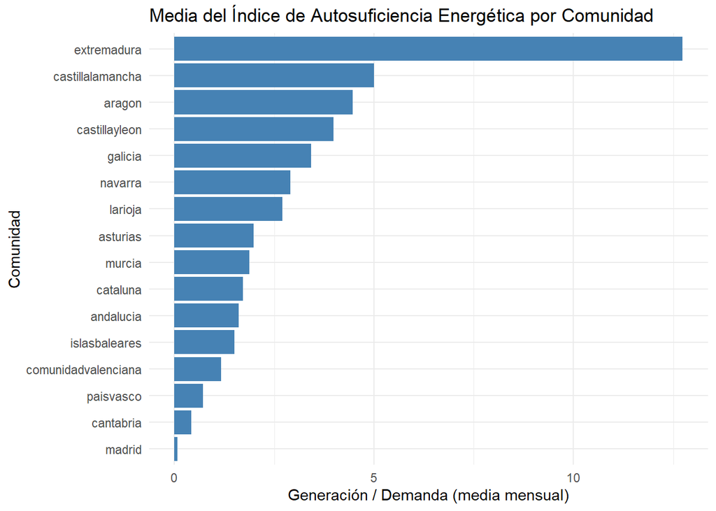

```r
library(ggplot2)

df_final %>%
  filter(!is.na(indice_autosuficiencia), is.finite(indice_autosuficiencia)) %>%
  group_by(comunidad) %>%
  summarise(media_autosuficiencia = mean(indice_autosuficiencia)) %>%
  ggplot(aes(x = reorder(comunidad, media_autosuficiencia), y = media_autosuficiencia)) +
  geom_col(fill = "steelblue") +
  coord_flip() +
  labs(title = "Media del Índice de Autosuficiencia Energética por Comunidad",
       x = "Comunidad", y = "Generación / Demanda (media mensual)") +
  theme_minimal()
```

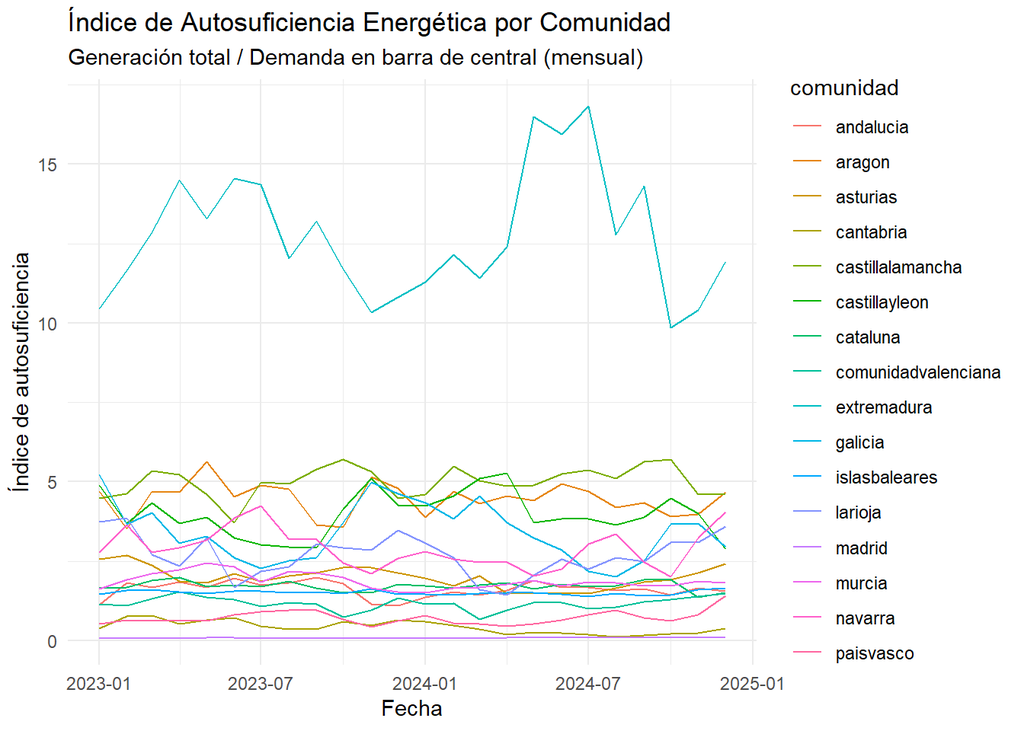

```r
library(ggplot2)

df_final %>%
  filter(!is.na(indice_autosuficiencia), is.finite(indice_autosuficiencia)) %>%
  ggplot(aes(x = fecha, y = indice_autosuficiencia, color = comunidad)) +
  geom_line() +
  labs(
    title = "Índice de Autosuficiencia Energética por Comunidad",
    subtitle = "Generación total / Demanda en barra de central (mensual)",
    x = "Fecha", y = "Índice de autosuficiencia"
  ) +
  theme_minimal()
```

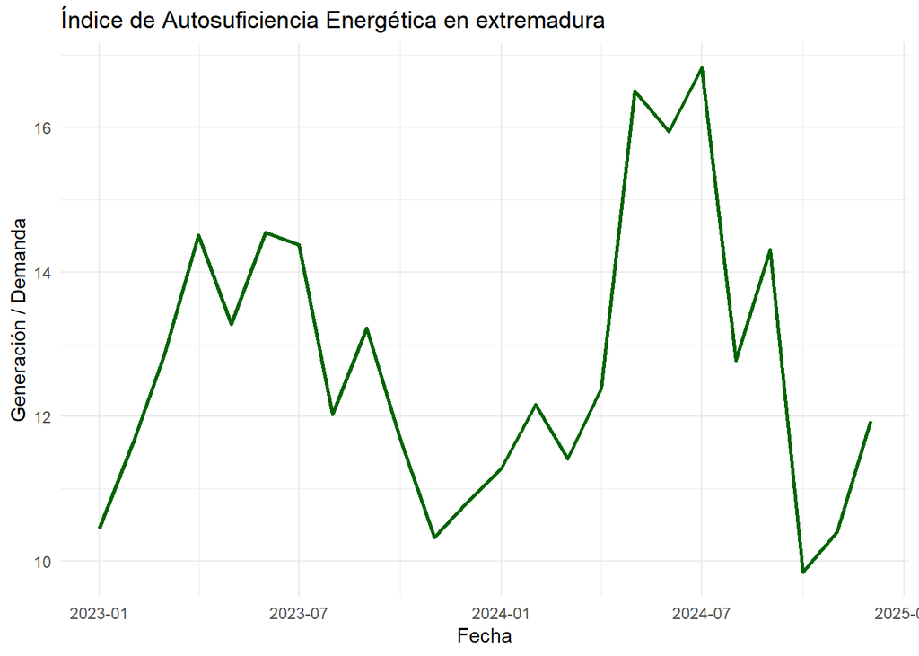

```r
df_final %>%
  filter(comunidad == "extremadura", !is.na(indice_autosuficiencia), is.finite(indice_autosuficiencia)) %>%
  ggplot(aes(x = fecha, y = indice_autosuficiencia)) +
  geom_line(color = "darkgreen", linewidth = 1) +
  labs(
    title = "Índice de Autosuficiencia Energética en extremadura",
    x = "Fecha", y = "Generación / Demanda"
  ) +
  theme_minimal()
```

```r
df_final %>%
  filter(comunidad == "extremadura") %>%
  select(fecha, generacion, demanda, indice_autosuficiencia) %>%
  arrange(fecha)
```

```
## # A tibble: 24 × 4
##    fecha      generacion demanda indice_autosuficiencia
##    <date>          <dbl>   <dbl>                  <dbl>
##  1 2023-01-01   4664910. 446121.                   10.5
##  2 2023-02-01   4751360. 407722.                   11.7
##  3 2023-03-01   5171334. 402237.                   12.9
##  4 2023-04-01   4997205. 344369.                   14.5
##  5 2023-05-01   4573250. 344277.                   13.3
##  6 2023-06-01   5586891. 384131.                   14.5
##  7 2023-07-01   6014827. 418467.                   14.4
##  8 2023-08-01   5874639. 488291.                   12.0
##  9 2023-09-01   4943057. 373874.                   13.2
## 10 2023-10-01   4438818. 379560.                   11.7
## # ℹ 14 more rows
```

```r
library(geodata)
library(sf)
```

```r
library(dplyr)
library(ggplot2)
library(stringr)
library(viridis)
# Descargar y convertir el mapa a sf
mapa_ccaa <- geodata::gadm(country = "ESP", level = 1, path = tempdir())
mapa_ccaa <- sf::st_as_sf(mapa_ccaa)

# Ver nombres disponibles para hacer match con tus datos
unique(mapa_ccaa$NAME_1)
```

```
##  [1] "Andalucía"                  "Aragón"
##  [3] "Cantabria"                  "Castilla-La Mancha"
##  [5] "Castilla y León"            "Cataluña"
##  [7] "Ceuta y Melilla"            "Comunidad de Madrid"
##  [9] "Comunidad Foral de Navarra" "Comunidad Valenciana"
## [11] "Extremadura"                "Galicia"
## [13] "Islas Baleares"             "Islas Canarias"
## [15] "La Rioja"                   "País Vasco"
## [17] "Principado de Asturias"     "Región de Murcia"
```

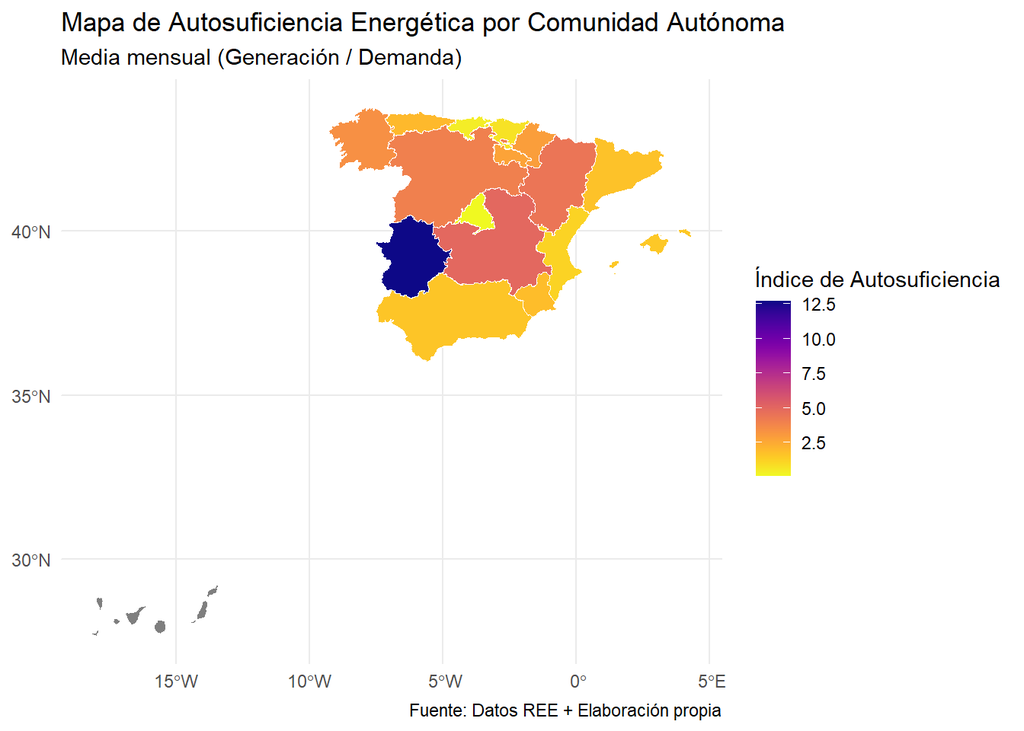

```r
# Procesar tus datos de autosuficiencia
media_autosuf <- df_final %>%
  filter(is.finite(indice_autosuficiencia)) %>%
  group_by(comunidad) %>%
  summarise(media_autosuficiencia = mean(indice_autosuficiencia, na.rm = TRUE)) %>%
  mutate(comunidad = str_replace_all(comunidad, "[[:space:]]", ""),  # limpieza extra
         comunidad = str_to_lower(comunidad)) %>%
  mutate(comunidad = case_when(
    comunidad == "andalucia" ~ "Andalucía",
    comunidad == "aragon" ~ "Aragón",
    comunidad == "asturias" ~ "Principado de Asturias",
    comunidad == "cantabria" ~ "Cantabria",
    comunidad == "castillalamancha" ~ "Castilla-La Mancha",
    comunidad == "castillayleon" ~ "Castilla y León",
    comunidad == "cataluna" ~ "Cataluña",
    comunidad == "comunidadvalenciana" ~ "Comunidad Valenciana",
    comunidad == "extremadura" ~ "Extremadura",
    comunidad == "galicia" ~ "Galicia",
    comunidad == "islasbaleares" ~ "Islas Baleares",
    comunidad == "islascanarias" ~ "Canarias",
    comunidad == "larioja" ~ "La Rioja",
    comunidad == "madrid" ~ "Comunidad de Madrid",
    comunidad == "murcia" ~ "Región de Murcia",
    comunidad == "navarra" ~ "Comunidad Foral de Navarra",
    comunidad == "paisvasco" ~ "País Vasco",
    TRUE ~ comunidad
  ))

# Unir mapa con datos
mapa_datos <- mapa_ccaa %>%
  left_join(media_autosuf, by = c("NAME_1" = "comunidad"))

# Pintar el mapa
ggplot(mapa_datos) +
  geom_sf(aes(fill = media_autosuficiencia), color = "white") +
  scale_fill_viridis(name = "Índice de Autosuficiencia", option = "C", direction = -1) +
  labs(
    title = "Mapa de Autosuficiencia Energética por Comunidad Autónoma",
    subtitle = "Media mensual (Generación / Demanda)",
    caption = "Fuente: Datos REE + Elaboración propia"
  ) +
  theme_minimal()
```

```r
mapa_datos %>%
  filter(is.na(media_autosuficiencia)) %>%
  pull(NAME_1)
```

```
## [1] "Ceuta y Melilla" "Islas Canarias"
```

Cálculo del Índice de Autosuficiencia Energética por Comunidad Autónoma

Objetivo del análisis:

Para realizar este estudio se ha trabajado con dos conjuntos de datos principales:

[output not shown]

Ambos conjuntos de datos abarcan los años 2023 y 2024, con periodicidad mensual y desagregación territorial por comunidad autónoma. Procesamiento y metodología

En primer lugar, fue necesario unificar y estandarizar los nombres de las comunidades autónomas en ambos conjuntos de datos para garantizar una correcta unión de la información. Esto incluyó la eliminación de espacios y tildes, la conversión a minúsculas y la unificación de denominaciones como “Castilla y León” o “País Vasco”.

Una vez normalizados los datos, se procedió a calcular el índice de autosuficiencia energética para cada comunidad autónoma y cada mes. Este índice se define como el cociente entre la energía generada y la energía demandada en un periodo determinado:

Indice de Autosuficiencia=Generacion/Demanda

```
Índice > 1: Comunidad excedentaria. Produce más energía de la que consume.

Índice ≈ 1: Comunidad autosuficiente. Su generación y demanda están equilibradas.

Índice < 1: Comunidad deficitaria. Necesita importar energía de otras regiones.
```

En la figura se muestra un mapa coroplético de España en el que se representa, mediante una escala de colores, el valor del índice de autosuficiencia energética medio mensual para cada comunidad autónoma.

El uso del color es fundamental para la interpretación:

```
Tonos amarillos representan bajos niveles de autosuficiencia (índices cercanos a 1 o menores), lo que indica una alta dependencia energética externa.

Tonos naranjas y rojizos indican un nivel medio de autosuficiencia, donde la generación cubre una buena parte de la demanda.

Tonos morados y azulados oscuros corresponden a regiones altamente autosuficientes, con índices muy superiores a 1, que generan un excedente significativo.
```

Este tipo de visualización resulta especialmente útil para identificar patrones regionales, diseñar políticas energéticas descentralizadas y priorizar inversiones en generación o redes en aquellas zonas con mayor déficit estructural.

Tras Extremadura, destacan también Castilla-La Mancha, Aragón, Castilla y León y Galicia, con valores comprendidos entre 3,4 y 5 puntos de autosuficiencia media. Estas comunidades poseen extensas superficies aptas para el desarrollo renovable, y una combinación equilibrada entre energía eólica, solar e hidráulica, permitiéndoles mantener una cobertura energética renovable significativamente elevada.

[output not shown]

En conjunto, el mapa de autosuficiencia energética proporciona una herramienta útil para identificar brechas, diseñar estrategias de planificación territorial sostenible y promover la equidad en el acceso a una energía limpia y segura en el conjunto del Estado

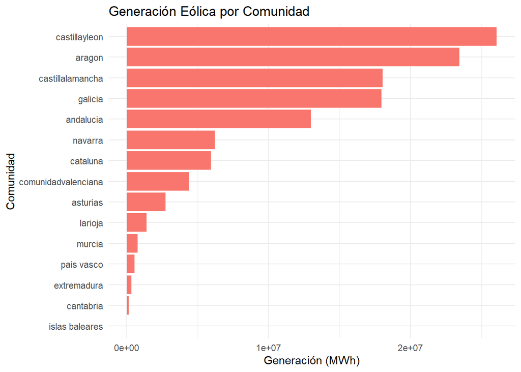

```r
library(dplyr)

renovables <- gen %>%
  filter(variable %in% c("Eólica", "Solar fotovoltaica", "Solar térmica", "Hidráulica", "Otras renovables")) %>%
  mutate(comunidad = tolower(comunidad)) %>%
  group_by(comunidad, variable) %>%
  summarise(generacion_total = sum(valor, na.rm = TRUE), .groups = "drop")


library(ggplot2)

ggplot(renovables %>% filter(variable == "Eólica"),
       aes(x = reorder(comunidad, generacion_total), y = generacion_total)) +
  geom_col(fill = "#F8766D") +
  coord_flip() +
  labs(
    title = "Generación Eólica por Comunidad",
    x = "Comunidad", y = "Generación (MWh)"
  ) +
  theme_minimal()
```

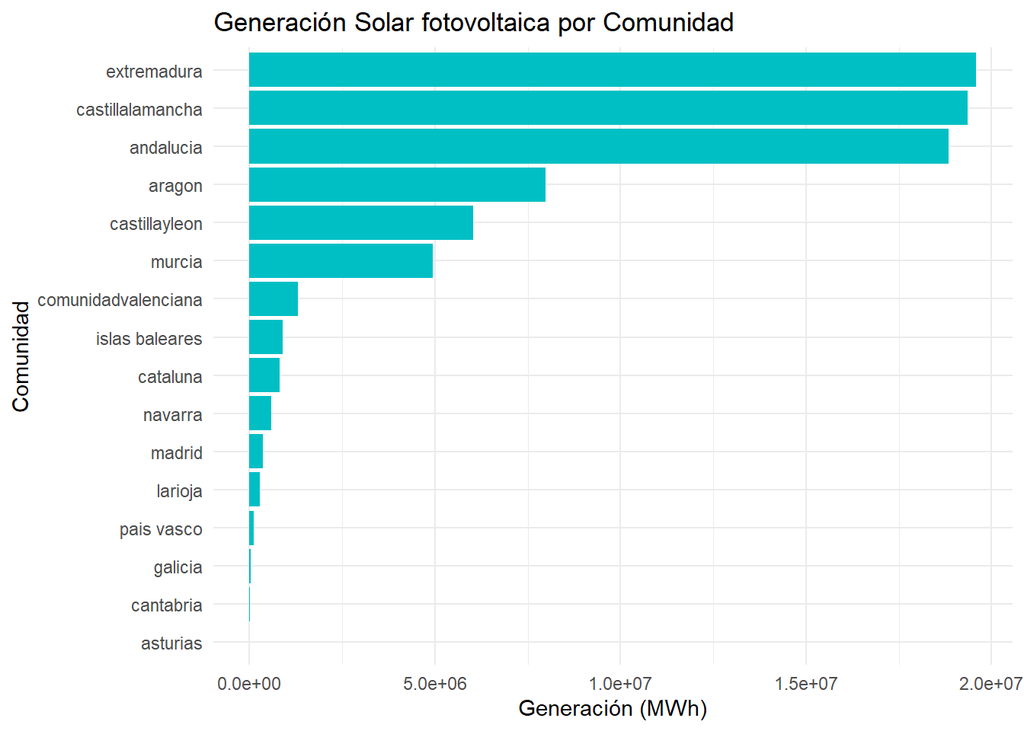

```r
ggplot(renovables %>% filter(variable == "Solar fotovoltaica"),
       aes(x = reorder(comunidad, generacion_total), y = generacion_total)) +
  geom_col(fill = "#00BFC4") +
  coord_flip() +
  labs(
    title = "Generación Solar fotovoltaica por Comunidad",
    x = "Comunidad", y = "Generación (MWh)"
  ) +
  theme_minimal()
```

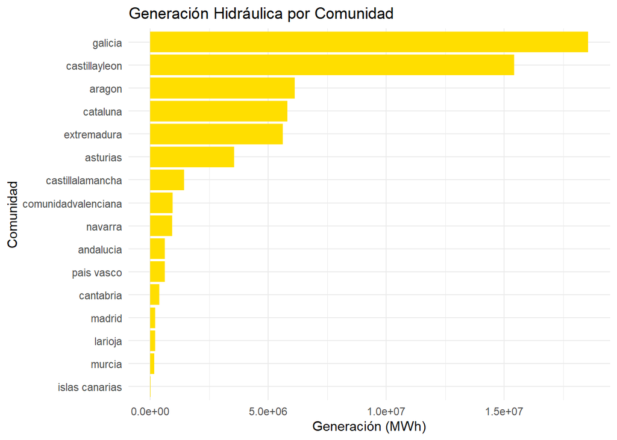

```r
ggplot(renovables %>% filter(variable == "Hidráulica"),
       aes(x = reorder(comunidad, generacion_total), y = generacion_total)) +
  geom_col(fill = "#FFDE00") +
  coord_flip() +
  labs(
    title = "Generación Hidráulica por Comunidad",
    x = "Comunidad", y = "Generación (MWh)"
  ) +
  theme_minimal()
```

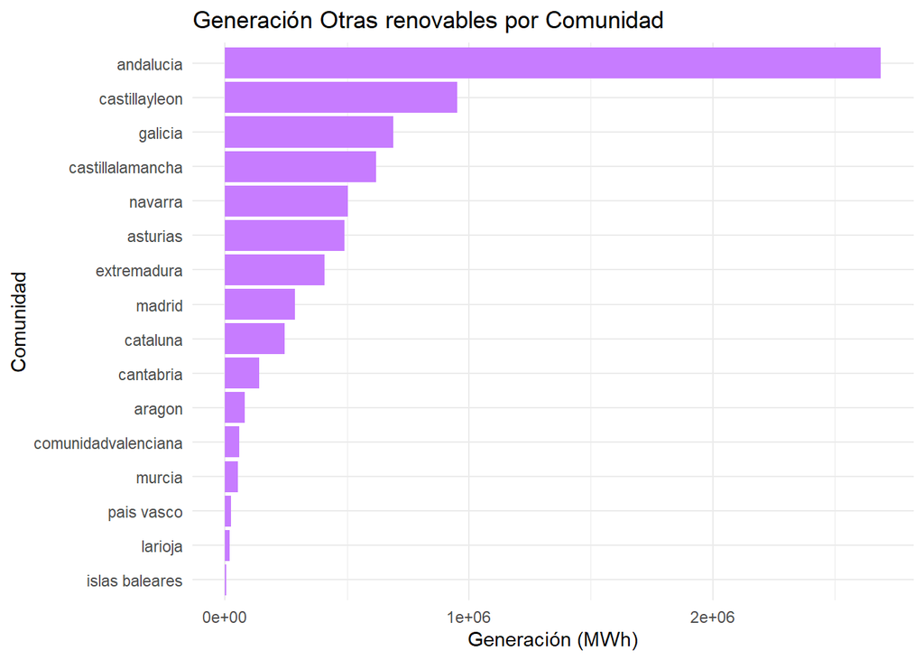

```r
ggplot(renovables %>% filter(variable == "Otras renovables"),
       aes(x = reorder(comunidad, generacion_total), y = generacion_total)) +
  geom_col(fill = "#C77CFF") +
  coord_flip() +
  labs(
    title = "Generación Otras renovables por Comunidad",
    x = "Comunidad", y = "Generación (MWh)"
  ) +
  theme_minimal()
```

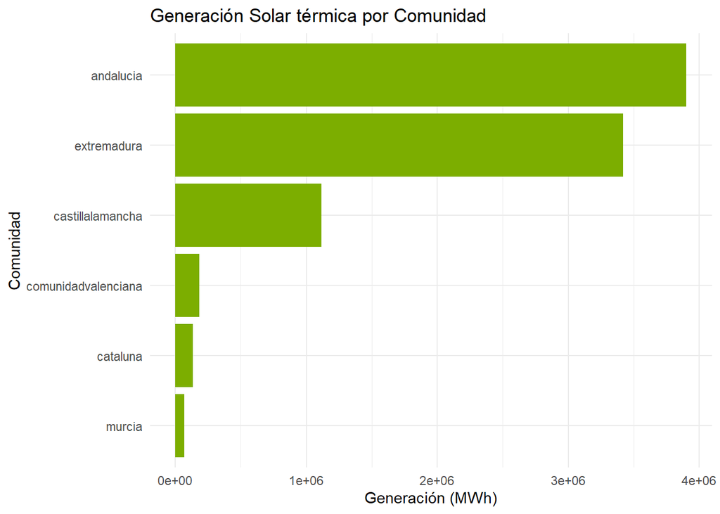

```r
ggplot(renovables %>% filter(variable == "Solar térmica"),
       aes(x = reorder(comunidad, generacion_total), y = generacion_total)) +
  geom_col(fill = "#7CAE00") +
  coord_flip() +
  labs(
    title = "Generación Solar térmica por Comunidad",
    x = "Comunidad", y = "Generación (MWh)"
  ) +
  theme_minimal()
```

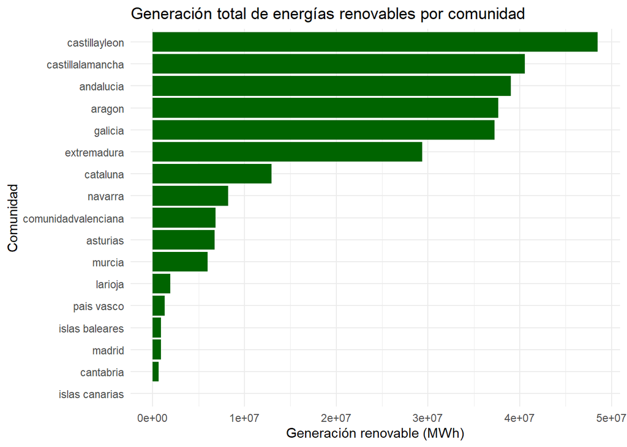

```r
library(dplyr)

renovables <- gen %>%
  filter(variable %in% c("Eólica", "Solar fotovoltaica", "Solar térmica", "Hidráulica", "Otras renovables")) %>%
  mutate(comunidad = tolower(comunidad))

renovables_comunidad <- renovables %>%
  group_by(comunidad) %>%
  summarise(generacion_renovable_total = sum(valor, na.rm = TRUE)) %>%
  arrange(desc(generacion_renovable_total))

library(ggplot2)

ggplot(renovables_comunidad, aes(x = reorder(comunidad, generacion_renovable_total), y = generacion_renovable_total)) +
  geom_col(fill = "darkgreen") +
  coord_flip() +
  labs(
    title = "Generación total de energías renovables por comunidad",
    x = "Comunidad", y = "Generación renovable (MWh)"
  ) +
  theme_minimal()
```

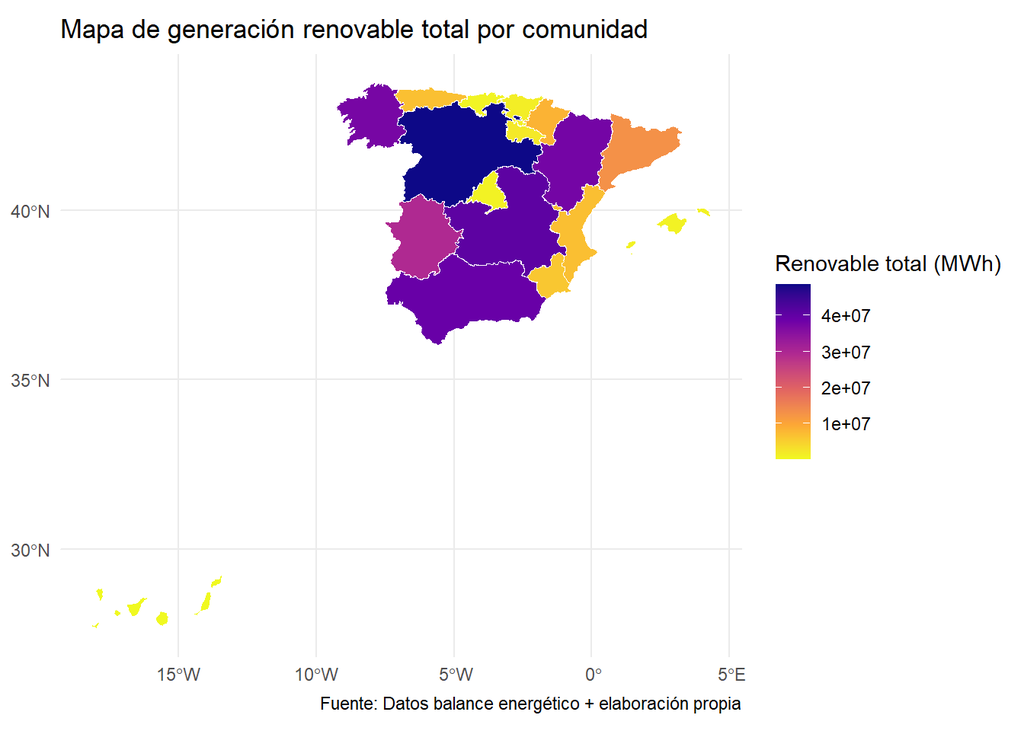

```r
library(stringr)

renovables_total <- renovables %>%
  group_by(comunidad) %>%
  summarise(generacion_renovable_total = sum(valor, na.rm = TRUE)) %>%
  arrange(desc(generacion_renovable_total))

mapa_ccaa <- sf::st_as_sf(mapa_ccaa)

# Normaliza nombres antes de unir
renovables_total <- renovables_total %>%
  mutate(comunidad = case_when(
    comunidad == "andalucia" ~ "Andalucía",
    comunidad == "aragon" ~ "Aragón",
    comunidad == "asturias" ~ "Principado de Asturias",
    comunidad == "cantabria" ~ "Cantabria",
    comunidad == "castillalamancha" ~ "Castilla-La Mancha",
    comunidad == "castillayleon" ~ "Castilla y León",
    comunidad == "cataluna" ~ "Cataluña",
    comunidad == "comunidadvalenciana" ~ "Comunidad Valenciana",
    comunidad == "extremadura" ~ "Extremadura",
    comunidad == "galicia" ~ "Galicia",
    comunidad == "islasbaleares" ~ "Islas Baleares",
    comunidad == "islascanarias" ~ "Canarias",
    comunidad == "larioja" ~ "La Rioja",
    comunidad == "madrid" ~ "Comunidad de Madrid",
    comunidad == "murcia" ~ "Región de Murcia",
    comunidad == "navarra" ~ "Comunidad Foral de Navarra",
    comunidad == "pais vasco" ~ "País Vasco",
    TRUE ~ str_to_title(comunidad)
  ))

# Join con el mapa
mapa_datos <- mapa_ccaa %>%
  left_join(renovables_total, by = c("NAME_1" = "comunidad"))

# Pintar
ggplot(mapa_datos) +
  geom_sf(aes(fill = generacion_renovable_total), color = "white") +
  scale_fill_viridis_c(option = "C", name = "Renovable total (MWh)", direction = -1) +
  labs(
    title = "Mapa de generación renovable total por comunidad",
    caption = "Fuente: Datos balance energético + elaboración propia"
  ) +
  theme_minimal()
```

```r
# App Shiny: Autosuficiencia por tipo de energía renovable
library(shiny)
library(dplyr)
library(ggplot2)
library(sf)
library(stringr)
library(viridis)
library(lubridate)
library(geodata)
library(readr)

# === Cargar datos ===
balance <- read_csv("balance_todas_comunidades.csv")
generacion <- read_csv("generacion_todas_comunidades.csv")
# === Normalizar nombres de comunidad ===
limpiar_comunidad <- function(df) {
  df %>%
    mutate(comunidad = str_replace_all(tolower(comunidad), "[[:space:]]", "")) %>%
    mutate(comunidad = case_when(
      comunidad == "andalucia" ~ "Andalucía",
      comunidad == "aragon" ~ "Aragón",
      comunidad == "asturias" ~ "Principado de Asturias",
      comunidad == "cantabria" ~ "Cantabria",
      comunidad == "castillalamancha" ~ "Castilla-La Mancha",
      comunidad == "castillayleon" ~ "Castilla y León",
      comunidad == "cataluna" ~ "Cataluña",
      comunidad == "comunidadvalenciana" ~ "Comunidad Valenciana",
      comunidad == "extremadura" ~ "Extremadura",
      comunidad == "galicia" ~ "Galicia",
      comunidad == "islasbaleares" ~ "Islas Baleares",
      comunidad == "islascanarias" ~ "Canarias",
      comunidad == "larioja" ~ "La Rioja",
      comunidad == "madrid" ~ "Comunidad de Madrid",
      comunidad == "murcia" ~ "Región de Murcia",
      comunidad == "navarra" ~ "Comunidad Foral de Navarra",
      comunidad == "paisvasco" ~ "País Vasco",
      TRUE ~ comunidad
    ))
}

# === Limpiar y procesar fechas ===
balance <- balance %>% mutate(fecha = as.Date(fecha)) %>% limpiar_comunidad()
generacion <- generacion %>% mutate(fecha = as.Date(fecha)) %>% limpiar_comunidad()

# === Calcular demanda total ===
demanda <- generacion %>%
  group_by(comunidad, fecha) %>%
  summarise(demanda = sum(valor, na.rm = TRUE), .groups = "drop")

# === Calcular índice de autosuficiencia por tipo de energía ===
df_auto <- balance %>%
  left_join(demanda, by = c("comunidad", "fecha")) %>%
  mutate(anio = year(fecha),
         energia = variable,
         indice_autosuf = valor / demanda) %>%
  # ⬇️ Filtrar solo energías renovables
  filter(energia %in% c("Hidráulica", "Solar fotovoltaica", "Solar térmica", "Otras renovables", "Eólica")) %>%
  group_by(comunidad, anio, energia) %>%
  summarise(indice_autosuf = mean(indice_autosuf, na.rm = TRUE), .groups = "drop")

# === Cargar mapa de comunidades autónomas ===
mapa_ccaa <- st_as_sf(geodata::gadm(country = "ESP", level = 1, path = tempdir()))

# === Unir datos al shapefile ===
auto_energia_sf <- mapa_ccaa %>%
  left_join(df_auto, by = c("NAME_1" = "comunidad"))

# === UI ===
ui <- fluidPage(
  titlePanel("Autosuficiencia por tipo de energía renovable"),
  sidebarLayout(
    sidebarPanel(
      selectInput("energia_input", "Tipo de energía:",
                  choices = c("Hidráulica", "Solar fotovoltaica", "Solar térmica", "Otras renovables", "Eólica")),
      selectInput("anio_input", "Año:",
                  choices = sort(unique(df_auto$anio)), selected = max(df_auto$anio))
    ),
    mainPanel(
      plotOutput("mapa")
    )
  )
)

# === SERVER ===
server <- function(input, output) {
  datos_filtrados <- reactive({
    auto_energia_sf %>%
      filter(energia == input$energia_input,
             anio == input$anio_input)
  })

  output$mapa <- renderPlot({
    ggplot(datos_filtrados()) +
      geom_sf(aes(fill = indice_autosuf), color = "white") +
      scale_fill_viridis(name = "Autosuficiencia", option = "C", direction = -1, na.value = "grey90") +
      labs(
        title = paste("Índice de autosuficiencia:", input$energia_input),
        subtitle = paste("Año:", input$anio_input),
        caption = "Fuente: REE + Elaboración propia"
      ) +
      theme_minimal()
  })
}

# === Ejecutar app ===
shinyApp(ui = ui, server = server)
```

Shiny applications not supported in static R Markdown documents

Análisis detallado por tipo de energía renovable

Con el objetivo de profundizar en el análisis de la autosuficiencia energética, se ha desarrollado una aplicación interactiva en R Shiny que permite visualizar y comparar el índice de autosuficiencia para cada una de las principales fuentes de energía renovable por comunidad autónoma. Esta herramienta ofrece una perspectiva más granular, facilitando la identificación de aquellas regiones que presentan un mayor grado de independencia energética en función de la tecnología utilizada.

Para ello, se han considerado únicamente las siguientes fuentes renovables:

```
-Hidráulica

-Solar fotovoltaica

-Solar térmica

-Otras renovables

-Eólica
```

Este cociente permite evaluar en qué medida una comunidad autónoma podría cubrir su demanda energética únicamente a través de una fuente renovable específica.

El mapa resultante, generado dinámicamente, permite seleccionar tanto el año como el tipo de energía, y visualizar en un único gráfico qué comunidades presentan una mayor autosuficiencia. Aquellas con un índice más alto están más cerca de cubrir su consumo con esa fuente concreta, mientras que las de menor valor son más dependientes de otras tecnologías o de importaciones externas.

Este enfoque desagregado es especialmente útil para:

```
Identificar fortalezas regionales por tipo de recurso (por ejemplo, comunidades con fuerte componente hidráulico o solar).

Valorar el equilibrio entre fuentes renovables y su distribución territorial.

Detectar oportunidades de mejora o inversión en infraestructuras específicas en función del recurso disponible.
```

Resultados: Energía Hidráulica

[output not shown]

Interpretación

El análisis por tipo de energía revela que ninguna comunidad alcanza la autosuficiencia exclusivamente a partir de generación hidráulica. Incluso en los mejores casos, el índice apenas supera el 15%-20% de la demanda. Esto refuerza la necesidad de diversificar las fuentes renovables para avanzar hacia un modelo energético más autosuficiente. Asimismo, destaca la desigualdad territorial en el acceso a recursos hidroeléctricos, lo que implica que las estrategias de transición energética deberán adaptarse a las características geográficas de cada región.

Resultados: Energía Eólica

[output not shown]

Interpretación

La energía eólica es, junto con la hidráulica, una de las fuentes renovables más consolidadas en España. Los datos confirman que hay comunidades que logran cubrir más del 20%-25% de su demanda eléctrica con esta fuente, especialmente en zonas con alta densidad de parques eólicos. Sin embargo, la autosuficiencia completa no se alcanza en ningún caso, lo que refuerza la necesidad de diversificación renovable. Además, se pone de manifiesto una asimetría territorial significativa, donde regiones del sur presentan aún amplio margen de desarrollo en esta tecnología.

Resultados: Energía Solar Fotovoltaica

```
2023: Destacan especialmente Andalucía, Extremadura, Castilla-La Mancha y Murcia, con los mayores niveles de autosuficiencia. Estas regiones alcanzan valores cercanos al 15% gracias a su elevada irradiación solar y a la expansión de instalaciones fotovoltaicas a gran escala. En contraste, las comunidades del norte y el área cantábrica muestran valores muy bajos.

2024: Se mantiene la misma distribución geográfica, pero con una leve mejora generalizada en las regiones líderes. Comunidad Valenciana y Madrid también reflejan aumentos modestos. La solar fotovoltaica se consolida como la fuente renovable dominante en el sur peninsular.
```

Interpretación

La energía solar fotovoltaica muestra una distribución geográfica muy marcada, con altas tasas de autosuficiencia en las regiones del sur y baja penetración en el norte. Esto es coherente con la disponibilidad de recurso solar y demuestra que el potencial de expansión sigue siendo alto. Aunque los niveles de autosuficiencia aún no alcanzan valores absolutos, su tendencia es claramente creciente. Esto hace de la fotovoltaica una pieza clave en la estrategia energética para regiones con alta demanda y elevado recurso solar.

Resultados: Energía Solar Térmica

[output not shown]

Interpretación

La solar térmica sigue teniendo un papel marginal en la generación eléctrica, ya que su uso está más orientado a la producción de calor (ACS, climatización, procesos industriales). Esta fuente, aunque técnicamente renovable, no contribuye significativamente a cubrir la demanda eléctrica regional, lo que explica los bajos índices de autosuficiencia. Su potencial podría aumentar si se integran tecnologías de concentración solar o se fomenta su hibridación con almacenamiento térmico.

Resultados: Otras Renovables

Los resultados muestran lo siguiente:

[output not shown]

Interpretación

Las denominadas “otras renovables” presentan gran potencial a nivel local, pero su implantación a escala regional sigue siendo baja. Están muy vinculadas a sectores concretos como la industria agroforestal, lo que restringe su desarrollo a determinadas zonas. Aunque su aportación al mix es limitada, podrían desempeñar un papel relevante en entornos rurales y economías circulares, especialmente si se integran en modelos de autoconsumo o microrredes.

Conclusión general del estudio de autosuficiencia energética por fuente renovable

El análisis detallado de los índices de autosuficiencia energética por fuente renovable a nivel regional en España ha puesto de manifiesto una realidad compleja, diversa y profundamente territorializada. A través de la combinación de datos de generación y demanda energética, y su visualización cartográfica mediante una aplicación interactiva desarrollada en Shiny, ha sido posible identificar los desequilibrios y patrones clave que caracterizan la sostenibilidad del sistema energético español en su dimensión renovable.

En primer lugar, ninguna comunidad autónoma alcanza la autosuficiencia energética total mediante una sola fuente renovable, lo que pone de manifiesto la imposibilidad de una dependencia exclusiva de un recurso, por abundante que sea. La autosuficiencia es un fenómeno parcial, altamente dependiente de factores como la disponibilidad natural de recursos (sol, viento, agua), el despliegue tecnológico, la infraestructura eléctrica y la demanda regional.

La energía hidráulica muestra una clara concentración en las regiones del norte, con valores máximos en Galicia, Cantabria y Castilla y León. Su irregularidad estacional y su dependencia de la hidrología la hacen poco fiable como pilar exclusivo.

La energía eólica ofrece una mayor penetración y mejores ratios de autosuficiencia, especialmente en Castilla y León, Galicia, Navarra o Aragón. Sin embargo, sigue siendo insuficiente por sí sola y revela fuertes contrastes entre comunidades.

En cuanto a la energía solar fotovoltaica, los resultados evidencian el liderazgo del sur peninsular: Andalucía, Extremadura, Castilla-La Mancha y Murcia muestran una gran ventaja comparativa. Este recurso se perfila como clave para avanzar hacia modelos autosuficientes en regiones con alta irradiación solar.

La solar térmica y las otras renovables (como biomasa o biogás) tienen un papel muy limitado en la generación eléctrica. Sus índices de autosuficiencia son residuales, lo que confirma que su impacto sigue siendo marginal en el mix energético nacional, aunque pueden ser útiles a pequeña escala y en aplicaciones específicas.

En conjunto, este estudio confirma que la autosuficiencia renovable regional es altamente desigual y dependiente del tipo de recurso. Algunas comunidades presentan claros avances y potencial (Castilla y León, Galicia, Extremadura), mientras que otras todavía dependen en gran medida de fuentes no renovables o importadas. Esta disparidad refuerza la necesidad de:

```
Fomentar la diversificación tecnológica para equilibrar las limitaciones de cada fuente.

Diseñar políticas energéticas adaptadas al perfil de cada comunidad.

Promover el desarrollo de redes inteligentes y almacenamiento para gestionar la intermitencia y excedentes.

Impulsar el autoconsumo y la generación distribuida, especialmente en regiones con baja autosuficiencia.
```

En definitiva, la autosuficiencia energética es un objetivo viable solo si se aborda de forma integrada, combinando múltiples fuentes renovables y adaptando las estrategias a las características territoriales de cada comunidad. Este estudio constituye una herramienta valiosa para identificar fortalezas, debilidades y oportunidades en la transición energética hacia un modelo más resiliente, sostenible y descentralizado.